# ALEXANDER LONGDI YILDET

[output not shown]

### Background:

Leveraging customer information is of paramount importance for most businesses. In the case of an insurance company, the attributes of customers can be crucial in making business decisions. Hence, knowing to explore and generate value out of such data can be an invaluable skill to have. As a Data Scientist in the Plateau Insurance company. The company wants to have a detailed understanding of the customer base for one of its Insurance Policy 'MediClaim'. The idea is to generate insights about the customers and answer a few key questions, by using the past dataset. The dataset 'pla_Insurance' contains customers' details like age, sex, charges, etc.

### Objective:

Explore the dataset and extract insights from the data. The idea is for you to get comfortable with doing analysis in Python. You are expected to do the following:

> Explore the dataset and extract insights using Exploratory Data Analysis.
> - Prove(or disprove) that the medical claims made by the people who smoke are greater than those who don't?
> - Prove (or disprove) with that the BMI of females is different from that of males.
> - Does the smoking habit of customers depend on their region?
> - Is the mean BMI of women with no children, one child, and two children the same?

#### Data Dictionary –

- Age - This is an integer indicating the age of the primary beneficiary (excluding those above 64 years, since they are generally covered by the government).
- Sex - This is the policy holder's gender, either male or female.
- BMI - This is the body mass index (BMI), which provides a sense of how over or underweight a person is relative to their height. BMI is equal to weight (in kilograms) divided by height (in meters) squared. An ideal BMI is within the range of 18.5 to 24.9.
- Children - This is an integer indicating the number of children/dependents covered by the insurance plan.
- Smoker - This is yes or no depending on whether the insured regularly smokes tobacco.
- Region - This is the beneficiary's place of residence in the U.S., divided into four geographic regions - northeast, southeast, southwest, or northwest.
- Charges - Individual medical costs billed to health insurance

### importing necesary libraries

```python
#import libraries
import pandas as pd
import numpy as np
```

```python
# datva importing and reading in of Data sets
df=pd.read_csv('plateau_Insurance.csv')
df
```

|  | age | sex | bmi | children | smoker | region | charges |
| --- | --- | --- | --- | --- | --- | --- | --- |
| 0 | 21 | female | 16.000 | 1 | no | northeast | 3167.45585 |
| 1 | 18 | male | 33.770 | 1 | no | southeast | 1725.55230 |
| 2 | 28 | male | 33.000 | 3 | no | southeast | 4449.46200 |
| 3 | 33 | male | 22.705 | 0 | no | northwest | 21984.47061 |
| 4 | 32 | male | 28.880 | 0 | no | northwest | 3866.85520 |
| ... | ... | ... | ... | ... | ... | ... | ... |
| 1333 | 50 | male | 30.970 | 3 | no | northwest | 10600.54830 |
| 1334 | 52 | female | 46.750 | 5 | no | southeast | 12592.53450 |
| 1335 | 54 | female | 47.410 | 0 | yes | southeast | 63770.42801 |
| 1336 | 37 | female | 47.600 | 2 | yes | southwest | 46113.51100 |
| 1337 | 46 | female | 48.070 | 2 | no | northeast | 9432.92530 |

1338 rows × 7 columns

```python
#assess the dataset's description
df.describe()
```

|  | age | bmi | children | charges |
| --- | --- | --- | --- | --- |
| count | 1338.000000 | 1338.000000 | 1338.000000 | 1338.000000 |
| mean | 39.207025 | 30.682687 | 1.094918 | 13270.422265 |
| std | 14.049960 | 6.145674 | 1.205493 | 12110.011237 |
| min | 18.000000 | 14.000000 | 0.000000 | 1121.873900 |
| 25% | 27.000000 | 26.315000 | 0.000000 | 4740.287150 |
| 50% | 39.000000 | 30.400000 | 1.000000 | 9382.033000 |
| 75% | 51.000000 | 34.700000 | 2.000000 | 16639.912515 |
| max | 64.000000 | 53.130000 | 5.000000 | 63770.428010 |

```python
#assess the dataset for data duplicates
df.duplicated().sum()
```

```
1
```

```python
#assess the dataset for missing data
df.isnull().sum()
```

```
age         0
sex         0
bmi         0
children    0
smoker      0
region      0
charges     0
dtype: int64
```

### EXPLORATTORY DATA ANALYSIS

### Univariate Analysis

```python
#importing visualization libraries
import seaborn as sns
import matplotlib.pyplot as plt
%matplotlib inline
```

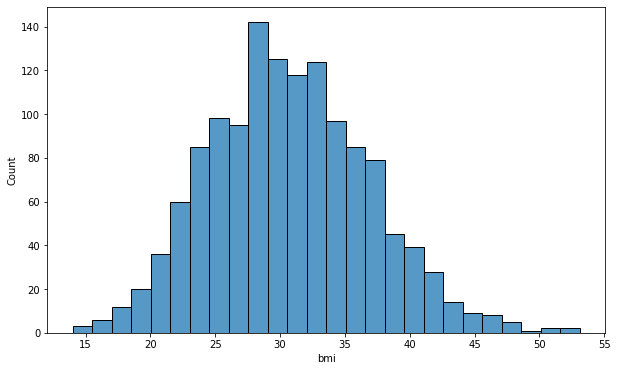

```python
#univariate analysis for the body mass index feature
plt.figure(figsize=(10,6))
sns.histplot(df.bmi)
```

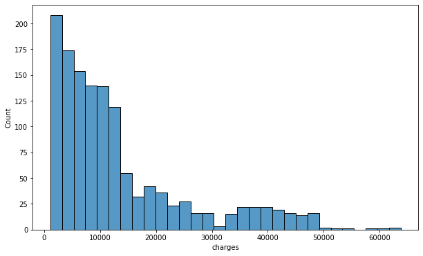

```python
#univariate analysis for the charges feature
plt.figure(figsize=(10,6))
sns.histplot(df.charges)
```

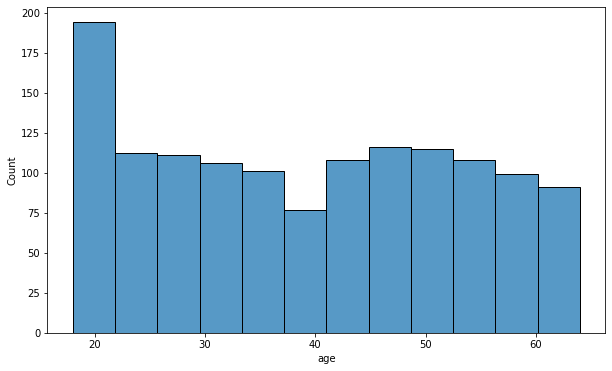

```python
#univariate analysis for the age feature
plt.figure(figsize=(10,6))
sns.histplot(df.age)
```

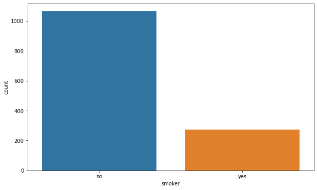

```python
#univariate analysis of the smoker feature
plt.figure(figsize=(10,6))
sns.countplot(x=df.smoker)
```

#### observations

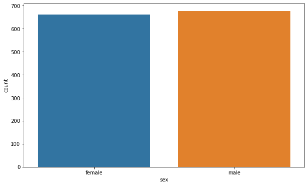

```python
#graphical visualiation of the sex feature
plt.figure(figsize=(10,6))
sns.countplot(x=df.sex)
```

```python
#According to this bar chart of the averagemeans of the sex feature, the BMIs of bothgenders do not differ much.
```

[output not shown]

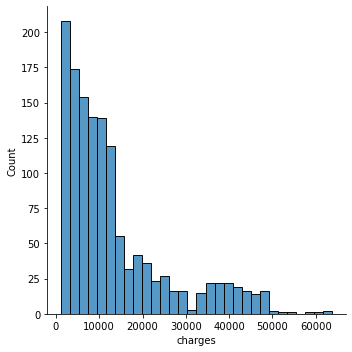

```python
#graphical visualiation of the target label(charges feature)
plt.figure(figsize=(10,6))
sns.displot(x=df.charges)
```